# Ecosystem Forecasting Project Report

Maria Popescu

#Part 1 – Model Description

##Model structure and rationale -My Forecast is predicting Deep Chlorophyll Maxima depth at FCR for the VERA forecasting challenge. I am choosing to forecast at FCR only because BVR recently had a draw-down that leads to some complexity when navigating training the model. BVR water levels have changed substantially while FCR water levels have not. -For my covariates, I am using Schmidt stability (derived from FLARE temperature profiles and FCR bathymetry), secchi depth (from FLARE), air temperature (from NOAA), wind speed (from NOAA using eastward and northward wind magnitude), and doy_sin/doy_cos to include seasonality. I only have driver uncertainty from my weather covariates (150 parameters). -I am using random forest for the model, and the hyperparameters are selected using a grid search with the best OOB r2 parameters being used for the final model. I split my training and testing data 80/20, and the residual standard deviation from the test data is used to include process uncertainty.

##Explanation of substantive novelty -My modelling approach is different than what we have developed in class together thus far. I am using random forest, and grid search hyperparameter tuning. I am also using FLARE output to train and predict my observations and am using new covariates (one of which I have to calculate within the model. I calculate schmidt stability from the bathymetry data and temperature profile output from FLARE).

##Uncertainty sources and implementation -My forecasts produce 150 ensemeble members to provide uncertainty. Though the FLARE output (schmidt stability and secchi depth) is summarized to a daily mean to reduce driver uncertainty, the weather ensembles are still cycled through to produce 150 ensemble members and integrated in the forecast to provide driver uncertainty. I also have process uncertainty from the test data sd of residuals which is added to each forecast.

##Responses from the registration form

Challenge: vera4cast model_id: fCMdepth_mp Long name: FCRE Chlorophyll Maximum Depth Random Forest Contact: Maria Popescu (mariapopescu100@gmail.com) Institution: Virginia Tech Code repository: https://github.com/MariaPopescu123/Maria_Forecasting_Project Model description modeling approach: Machine learning Describe your modeling approach: Using FLARE output of Secchi depth and temperature profiles (to calculate Schmidt stability), and NOAA output of wind speed and air temperature as covariates, random forest is used to predict chlorophyll maximum depth at Falling Creek Reservoir. Sources of Forecast Uncertainty Does the forecast use drivers?Yes Does the forecast include uncertainty from drivers?Yes Model drivers: Schmidt stability, Secchi depth, air temperature, wind speed Is the forecast model dynamic?No Initial condition uncertainty?No Does the model include parameters?Yes, and at least one is estimated from data Parameter uncertainty?No Do you update your initial conditions or parameters between forecast submissions using newly available data (i.e., data assimilation)? Parameters What method did you use if you updated your initial conditions or parameters using data assimilation? Model refitting Does your forecast include uncertainty from the model (process uncertainty)? Yes and the uncertainty was estimated from data Does your forecast include uncertainty from measurement noise? No Does your forecast include uncertainty from using different models? No Does your forecast include uncertainty from parameter random effects? No

#Part 2 – Reforecast Analysis Definition A reforecast mimics real‑time forecasting for a past period. Required Properties Must span at least 1 year Each forecast must use only data available at its reference_datetime No future observations No observed covariates beyond the reference_datetime Only driver forecasts that would have been available at the time Data leakage invalidates the reforecast. Do not use the submit function in your reforecast code to avoid submission to the Challenge.

Baseline Comparisons Baseline scores (climatology and persistence) are accessed directly from the challenge catalog; you do not generate them yourself.

Performance evaluated across multiple axes: Forecast horizon Sites Season or time of year Comparison with baseline models Written interpretation of results

1. Accessing climatology, persistence, and using MY MODEL for DCM depth

```r
library(tidyverse)
library(arrow)
library(kableExtra)
library(scoringRules)
library(duckdbfs)
#updated
targets <- read_csv("https://amnh1.osn.mghpcc.org/bio230121-bucket01/vera4cast/targets/project_id=vera4cast/duration=P1D/daily-insitu-targets.csv.gz")
```

#Downloading all the forecasts generated by climatology and persistence. I am going to do from April 2025-April 2026

```r
all_forecasts_full <- duckdbfs::open_dataset(
  "s3://anonymous@bio230121-bucket01/vera4cast/forecasts/bundled-summaries/project_id=vera4cast?endpoint_override=amnh1.osn.mghpcc.org",
  anonymous = TRUE
) |>
  filter(reference_datetime >= as_datetime("2025-04-01 00:00:00"),
         reference_datetime <= as_datetime("2026-04-01 00:00:00"),
         site_id == "fcre",
         model_id %in% c("climatology", "persistenceRW")) |>
  collect()
#to be able to plot performance over the course of horizon I need a column for horizon


#write_csv(all_forecasts_full, "all_forecasts_full.csv")
```

#plotting observations since 2024 (because FLARE output, for my covariates only available past 2024-05)

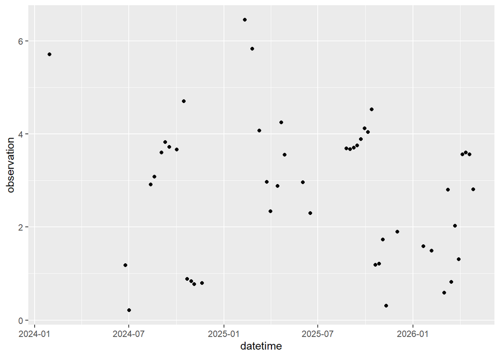

```r
target_variable <- "ChlorophyllMaximum_depth_sample"
focal_site <- "fcre"

targets_check <- targets |>
  mutate(datetime = as_datetime(datetime))|>
  filter(datetime >= as_datetime("2024-01-01 00:00:00"),
         variable == target_variable,
         site_id == "fcre")

ggplot(targets_check, aes(x = datetime, y = observation))+
  geom_point()
```

#Just plotting observations for April

```r
targets_single_forecast <- targets |>
  mutate(datetime = as_datetime(datetime))|>
  filter(datetime >= as_datetime("2025-04-01 00:00:00"),
         datetime <= as_datetime("2025-05-01 00:00:00"),
         variable == target_variable,
         site_id == "fcre")

plot_reference_date <- as_date("2025-04-01")

# Climatology
clim_summary <- all_forecasts_full |>
  filter(model_id == "climatology", variable == target_variable,
         as_date(reference_datetime) == plot_reference_date) |>
    group_by(datetime, model_id) |>
  summarise(mu = mean(mean),
            lower_2.5 = quantile02.5,
            upper_97.5 = quantile97.5,
            .groups = "drop")

# Persistence models
#family is also normal here
pers_summary <- all_forecasts_full |>
  filter(model_id == "persistenceRW", variable == target_variable,
         as_date(reference_datetime) == plot_reference_date) |>
    group_by(datetime, model_id) |>
  summarise(mu = mean(mean),
            lower_2.5 = quantile02.5,
            upper_97.5 = quantile97.5,
            .groups = "drop")

my_forecasts_full <- read_csv("R/my_forecasts_full.csv")
my_forecasts_full|>
  arrange(reference_datetime, datetime, parameter)
```

```
# A tibble: 270,300 × 11
   datetime   reference_datetime duration site_id depth_m family   parameter
   <date>     <date>             <chr>    <chr>   <lgl>   <chr>        <dbl>
 1 2025-04-02 2025-04-01         P1D      fcre    NA      ensemble         1
 2 2025-04-02 2025-04-01         P1D      fcre    NA      ensemble         2
 3 2025-04-02 2025-04-01         P1D      fcre    NA      ensemble         3
 4 2025-04-02 2025-04-01         P1D      fcre    NA      ensemble         4
 5 2025-04-02 2025-04-01         P1D      fcre    NA      ensemble         5
 6 2025-04-02 2025-04-01         P1D      fcre    NA      ensemble         6
 7 2025-04-02 2025-04-01         P1D      fcre    NA      ensemble         7
 8 2025-04-02 2025-04-01         P1D      fcre    NA      ensemble         8
 9 2025-04-02 2025-04-01         P1D      fcre    NA      ensemble         9
10 2025-04-02 2025-04-01         P1D      fcre    NA      ensemble        10
# ℹ 270,290 more rows
# ℹ 4 more variables: variable <chr>, prediction <dbl>, model_id <chr>,
#   project_id <chr>
```

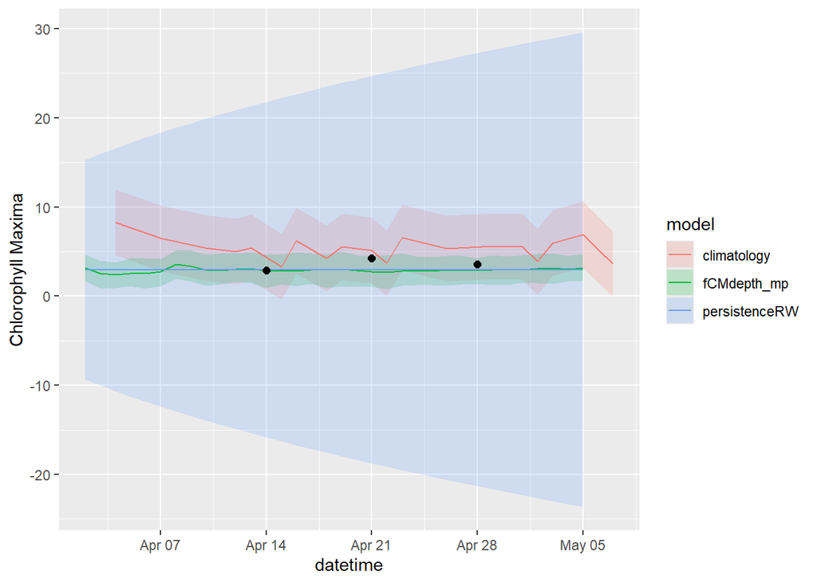

```r
#from reforecasting assignment
mine_summary <- my_forecasts_full |>
  filter(as_date(reference_datetime) == plot_reference_date)|>
  group_by(datetime, model_id)|>
  summarise(mu = mean(prediction),
            lower_2.5 = quantile(prediction, 0.025),
            upper_97.5 = quantile(prediction, 0.975),
            .groups = "drop")

summarized_forecasts <- bind_rows(clim_summary, pers_summary, mine_summary)

ggplot(summarized_forecasts, aes(x = datetime, color = model_id, fill = model_id)) +
  geom_ribbon(aes(ymin = lower_2.5, ymax = upper_97.5), alpha = 0.2, color = NA) +
  geom_line(aes(y = mu)) +
  geom_point(data = targets_single_forecast,
             aes(x = datetime, y = observation),
             inherit.aes = FALSE, color = "black", size = 2) +
  labs(y = "Chlorophyll Maxima", color = "model", fill = "model")
```

#September observations

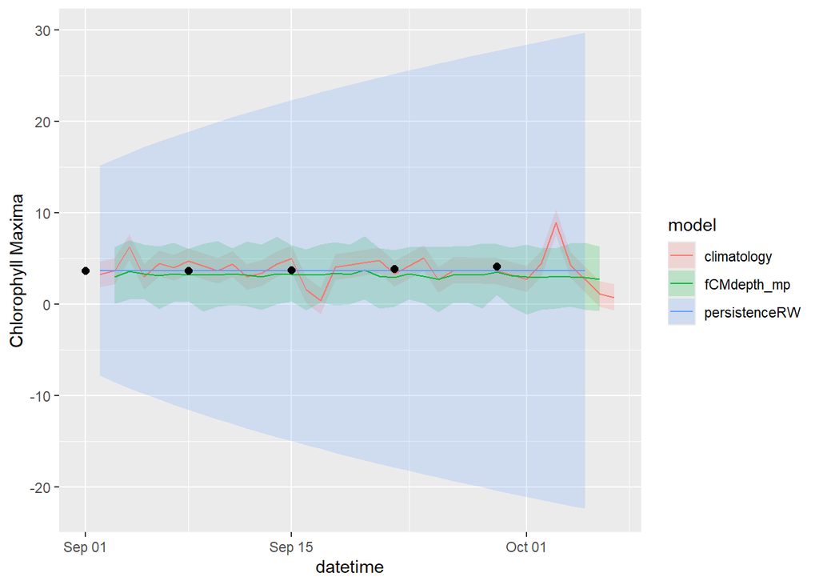

```r
targets_single_forecast <- targets |>
  mutate(datetime = as_datetime(datetime))|>
  filter(datetime >= as_datetime("2025-09-01 00:00:00"),
         datetime <= as_datetime("2025-10-01 00:00:00"),
         variable == target_variable,
         site_id == "fcre")

plot_reference_date <- as_date("2025-09-01")

# Climatology
clim_summary <- all_forecasts_full |>
  filter(model_id == "climatology", variable == target_variable,
         as_date(reference_datetime) == plot_reference_date) |>
    group_by(datetime, model_id) |>
  summarise(mu = mean(mean),
            lower_2.5 = quantile02.5,
            upper_97.5 = quantile97.5,
            .groups = "drop")

# Persistence models
#family is also normal here
pers_summary <- all_forecasts_full |>
  filter(model_id == "persistenceRW", variable == target_variable,
         as_date(reference_datetime) == plot_reference_date) |>
    group_by(datetime, model_id) |>
  summarise(mu = mean(mean),
            lower_2.5 = quantile02.5,
            upper_97.5 = quantile97.5,
            .groups = "drop")

#from reforecasting assignment
mine_summary <- my_forecasts_full |>
  filter(as_date(reference_datetime) == as_date("2025-09-02"))|> #have to be specific because mine is every 7 days
  group_by(datetime, model_id)|>
  summarise(mu = mean(prediction),
            lower_2.5 = quantile(prediction, 0.025),
            upper_97.5 = quantile(prediction, 0.975),
            .groups = "drop")

summarized_forecasts <- bind_rows(clim_summary, pers_summary, mine_summary)

ggplot(summarized_forecasts, aes(x = datetime, color = model_id, fill = model_id)) +
  geom_ribbon(aes(ymin = lower_2.5, ymax = upper_97.5), alpha = 0.2, color = NA) +
  geom_line(aes(y = mu)) +
  geom_point(data = targets_single_forecast,
             aes(x = datetime, y = observation),
             inherit.aes = FALSE, color = "black", size = 2) +
  labs(y = "Chlorophyll Maxima", color = "model", fill = "model")
```

#Calculating CRPS for climatology, persistence, and my model for all reference datetimes and horizons. Which model has the lower score when you consider all submissions?

```r
target_variable <- "ChlorophyllMaximum_depth_sample"
focal_site <- "fcre"

obs_all <- targets |>
  mutate(datetime = as_date(datetime)) |>
  filter(variable == target_variable, site_id == focal_site) |>
  select(datetime, site_id, observation)

# Climatology (normal)
#only goes from 2025-01-08 - 2026-01-01
dates_in_mine <- unique(my_forecasts_full$reference_datetime)

clim_all <- all_forecasts_full |>
  filter(model_id == "climatology",
         variable == target_variable) |>
  inner_join(obs_all, by = c("datetime", "site_id")) |>
  filter(!is.na(observation), !is.na(mean), !is.na(sd)) |>
  mutate(crps = crps_norm(y = observation, mean = mean, sd = sd)) |>
  select(reference_datetime, datetime, site_id, variable, model_id, crps)|>
  mutate(reference_datetime = as_date(reference_datetime))|>
  filter(reference_datetime %in% dates_in_mine)

#family is normal here

# Persistence models
#family is also normal here
pers_all <- all_forecasts_full |>
  filter(model_id == "persistenceRW",
         variable == target_variable) |>
  inner_join(obs_all, by = c("datetime", "site_id")) |>
  filter(!is.na(observation), !is.na(mean), !is.na(sd)) |>
  mutate(crps = crps_norm(y = observation, mean = mean, sd = sd)) |>
  select(reference_datetime, datetime, site_id, variable, model_id, crps)|>
  mutate(reference_datetime = as_date(reference_datetime))|>
  filter(reference_datetime %in% dates_in_mine)
```

#My forecast loaded in from R/Popescu_CM_reforecast.R

```r
my_forecasts_full <- read_csv("R/my_forecasts_full.csv")
my_forecasts_full|>
  arrange(reference_datetime, datetime, parameter)
```

```
# A tibble: 270,300 × 11
   datetime   reference_datetime duration site_id depth_m family   parameter
   <date>     <date>             <chr>    <chr>   <lgl>   <chr>        <dbl>
 1 2025-04-02 2025-04-01         P1D      fcre    NA      ensemble         1
 2 2025-04-02 2025-04-01         P1D      fcre    NA      ensemble         2
 3 2025-04-02 2025-04-01         P1D      fcre    NA      ensemble         3
 4 2025-04-02 2025-04-01         P1D      fcre    NA      ensemble         4
 5 2025-04-02 2025-04-01         P1D      fcre    NA      ensemble         5
 6 2025-04-02 2025-04-01         P1D      fcre    NA      ensemble         6
 7 2025-04-02 2025-04-01         P1D      fcre    NA      ensemble         7
 8 2025-04-02 2025-04-01         P1D      fcre    NA      ensemble         8
 9 2025-04-02 2025-04-01         P1D      fcre    NA      ensemble         9
10 2025-04-02 2025-04-01         P1D      fcre    NA      ensemble        10
# ℹ 270,290 more rows
# ℹ 4 more variables: variable <chr>, prediction <dbl>, model_id <chr>,
#   project_id <chr>
```

```r
dates_in_clim_all <- unique(clim_all$reference_datetime)
dates_in_pers_all <- unique(pers_all$reference_datetime)

#from reforecasting assignment
mine_all <- my_forecasts_full |>
  inner_join(obs_all, by = "datetime") |>
  filter(!is.na(observation), !is.na(prediction)) |>
  group_by(reference_datetime, datetime, model_id) |>
  filter(reference_datetime %in% dates_in_clim_all,
         reference_datetime %in% dates_in_pers_all)|>
  summarise(
    crps = crps_sample(y = unique(observation), dat = prediction),
    .groups = "drop"
  )

#check
check <- my_forecasts_full|>
  mutate(horizon = as.numeric(datetime - as_date(reference_datetime)))|>
  count(horizon)|>
  arrange(horizon)

crps_full <- bind_rows(clim_all, pers_all, mine_all)|>
  mutate(horizon = as.numeric(difftime(datetime, reference_datetime, units = "days")))|> #for the horizon
  filter(reference_datetime %in% dates_in_clim_all,
         reference_datetime %in% dates_in_pers_all)

mean_crps_by_horizon <- crps_full |>
  group_by(model_id, horizon) |>
  summarise(mean_crps = mean(crps, na.rm = TRUE),
            n = n(),
            .groups = "drop")
```

#mean crps by horizon

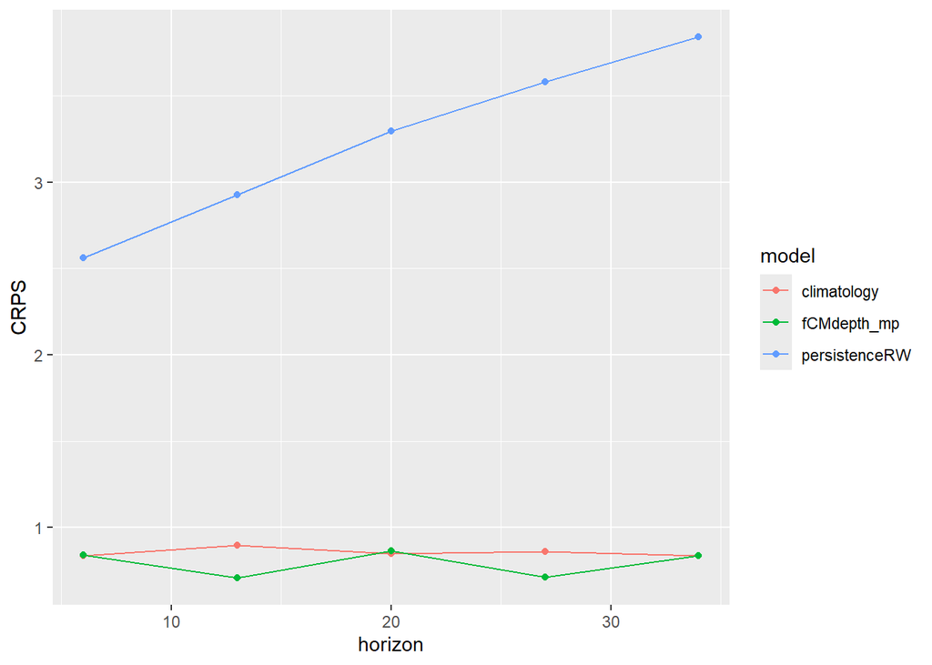

```r
ggplot(mean_crps_by_horizon, aes(x = horizon, y = mean_crps, color = model_id))+
  geom_line() +
  geom_point() +
  labs(x = "horizon", y = "CRPS", color = "model")
```

#could also do by date

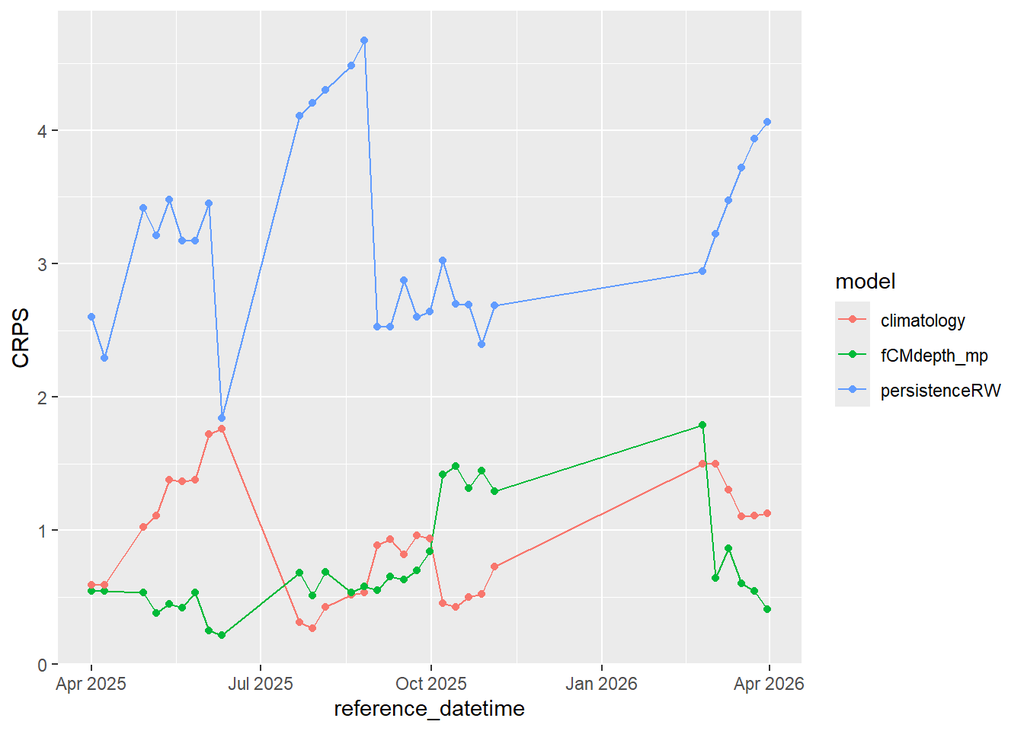

```r
mean_crps_by_date <- crps_full |>
  group_by(model_id, reference_datetime) |>
  summarise(mean_crps = mean(crps, na.rm = TRUE),
            n = n(),
            .groups = "drop") |>
  arrange(mean_crps)

ggplot(mean_crps_by_date, aes(x = reference_datetime, y = mean_crps, color = model_id))+
  geom_line() +
  geom_point() +
  labs(x = "reference_datetime", y = "CRPS", color = "model")
```

#Now to see by horizon if I filter for just the summer

```r
mean_crps_by_horizon_summer <- crps_full |>
  filter(lubridate::month(reference_datetime) >= 3,
         lubridate::month(reference_datetime) <= 10) |>
  group_by(model_id, horizon) |>
  summarise(mean_crps = mean(crps, na.rm = TRUE),
            n = n(),
            .groups = "drop")
```

#mean crps by horizon

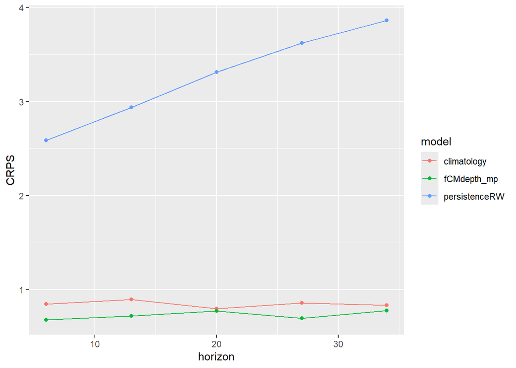

```r
ggplot(mean_crps_by_horizon_summer, aes(x = horizon, y = mean_crps, color = model_id))+
  geom_line() +
  geom_point() +
  labs(x = "horizon", y = "CRPS", color = "model")
```

#written interpretation of results

When removing the winter months, my forecast is the best performing forecast.

#Part 3 – Reproducibility Checklist Include: model_id: “fCMdepth_mp” GitHub repository link (this is a new repo): https://github.com/MariaPopescu123/Maria_Forecasting_Project

Link to forecast‑generation code: https://github.com/MariaPopescu123/Maria_Forecasting_Project/blob/main/Submit_forecast/mp_CMdepth_Forecast.R

and the helper function: https://github.com/MariaPopescu123/Maria_Forecasting_Project/blob/main/R/helper_functions.R

Link to Quarto (.qmd) report: https://github.com/MariaPopescu123/Maria_Forecasting_Project/blob/main/Project_Report.qmd

also here is my reforecast script: https://github.com/MariaPopescu123/Maria_Forecasting_Project/blob/main/R/Popescu_CM_reforecast.R

Evidence of multiple automated forecasts: https://github.com/MariaPopescu123/Maria_Forecasting_Project/actions/workflows/run_forecast.yaml

Link to model entry in the challenge catalog:

```r
#this is from VERA
all_results <- arrow::open_dataset("s3://anonymous@bio230121-bucket01/vera4cast/forecasts/bundled-summaries/project_id=vera4cast?endpoint_override=amnh1.osn.mghpcc.org")
df <- all_results |>
  filter(model_id == "fCMdepth_mp")|>
  dplyr::collect()
```